# DS 202: Lab 5

Muhammad Khairi Norizan

11/15/2021

## Question 1

Create a data frame containing the persons who are fatally hurt in the accidents (see FARS manual and look up variable `INJ_SEV`)

```r
fatallyInjuredPerson <- person %>% filter(INJ_SEV == 4)
```

## Question 2

Create a data frame containing the most dangerous vehicle make in each state. The number of persons fatally hit in the vehicle make is used to assess the non-safety of a make. Make sure to handle the missing values appropriately. (look up variable `MAKE`)

```r
# MAKE, STATE, PER_NO, PER_TYPE
# PER_TYPE; 1 = Driver of a Motor Vehicle in Transport, 2 = Passenger of a Motor Vehicle in Transport

dangerousVehicleByState <- fatallyInjuredPerson %>%
                            filter(PER_TYP %in% c(1,2)) %>%
                            select(STATE, PER_NO, MAKE, PER_TYP, INJ_SEV) %>%
                            group_by(STATE, MAKE) %>%
                            summarize(TotalPersonFatallyHit = sum(PER_NO, na.rm = TRUE)) %>%
                            slice(which.max(TotalPersonFatallyHit))

print(dangerousVehicleByState)
```

```
## # A tibble: 51 × 3
## # Groups:   STATE [51]
##    STATE  MAKE TotalPersonFatallyHit
##    <int> <int>                 <int>
##  1     1    12                   188
##  2     2    20                    12
##  3     4    20                   137
##  4     5    20                   113
##  5     6    49                   469
##  6     8    20                    96
##  7     9    37                    34
##  8    10    12                    14
##  9    11    42                     8
## 10    12    12                   312
## # … with 41 more rows
```

## Question 3

Create a map, and label each state with the most dangerous vehicle. Discuss the definition of the most dangerous vehicle, and what you find from the map. (Hint: Read the description for the `STATE` and `COUNTY` columns in the FARS manual. The state & county codes are Geographic Locator Codes (GLCs) from the General Services Administration’s (GSA) publication. Use `readxl::read_xlsx` to read in the GLCs.)

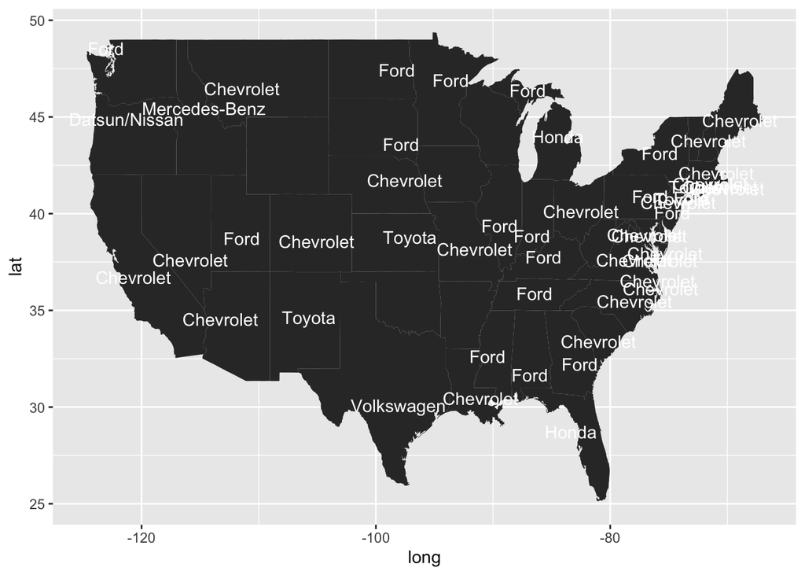

```r
states <- map_data("state")
glc <- read_excel('./data/FRPP_GLC_-_United_StatesNov42021.xlsx', sheet = "GeoLocation_UnitedStates")
carmake <- read_excel('./data/car_make.xlsx', sheet = "Sheet1")

dangerousMakeByState <- dangerousVehicleByState %>% inner_join(carmake, by=c("MAKE" = "ID"))

joinedDf <- dangerousMakeByState %>% left_join(states, by=c("STATE" = "group"))

groupedJoinedDf <- joinedDf %>% group_by(STATE, Make) %>% summarize(long=mean(long), lat=mean(lat))

states %>% ggplot(aes(x = long, y = lat)) +
            geom_polygon(aes(group = group)) +
            geom_text(aes(label=Make), color='white', data=groupedJoinedDf)
```

A dangerous vehicle can be classified as a vehicle that have the most number of person which have been fatally hit. For instance, Alabama’s most dangerous vehicle is Ford since Ford has the most number of people that have been fatally hit (188). From the map above, we can see that, Chevrolet is the most dangerous vehicle in the United State since Chevrolet has caused most fatal accident in most of the states. However, most cases that involved Chevrolet are usually on the east side of the United States.

## Question 4

Join the accident and person table (work out which variable(s) to use)

```r
personAccident <- person %>% inner_join(accident, by='ST_CASE')
```

## Question 5

Tally the number of accidents by day of the week (`DAY_WEEK`), hour of the day (`HOUR`) and gender (`SEX`). Visualize the results and explain what you find.

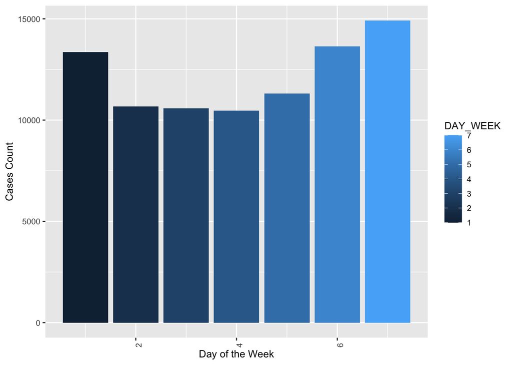

```r
# geom_bar
dayWeek <- personAccident %>% group_by(DAY_WEEK) %>% summarize(CasesCount = n())
# geom_line
hour <- personAccident %>% filter(HOUR.x != 99) %>% group_by(HOUR.x) %>% summarize(CasesCount = n())
# geom_bar
sex <- personAccident %>% filter(SEX %in% c(1,2)) %>% group_by(SEX) %>% summarize(CasesCount = n())

ggplot(dayWeek, aes(x=DAY_WEEK, y=CasesCount, fill = DAY_WEEK)) +
  geom_bar(stat = "identity") +
  theme(text = element_text(size=10), axis.text.x = element_text(angle = 90, hjust=1)) +
  labs(y = "Cases Count", x = "Day of the Week")
```

**Day of the Week vs Cases Count**  
From the barplot Day of the Week vs Cases Count, we can see an upward trend from Wednesday to Saturday. Apart from that, we can also see that Saturday has the most number of accident cases and Wednesday has the lowest number of accident cases.

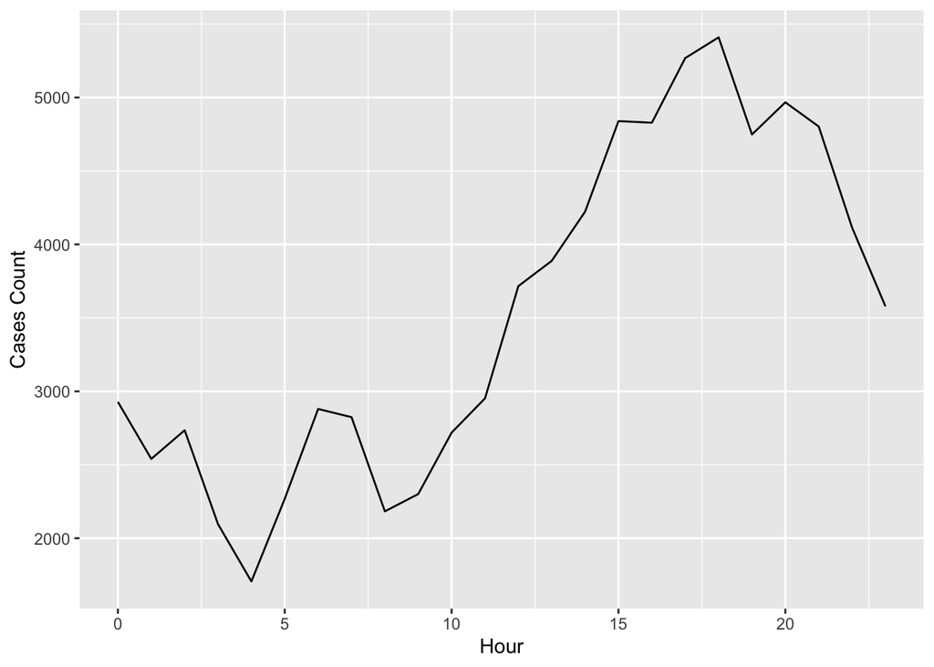

```r
ggplot(hour) +
  geom_line(aes(x=HOUR.x, y=CasesCount)) +
  labs(y = "Cases Count", x = "Hour")
```

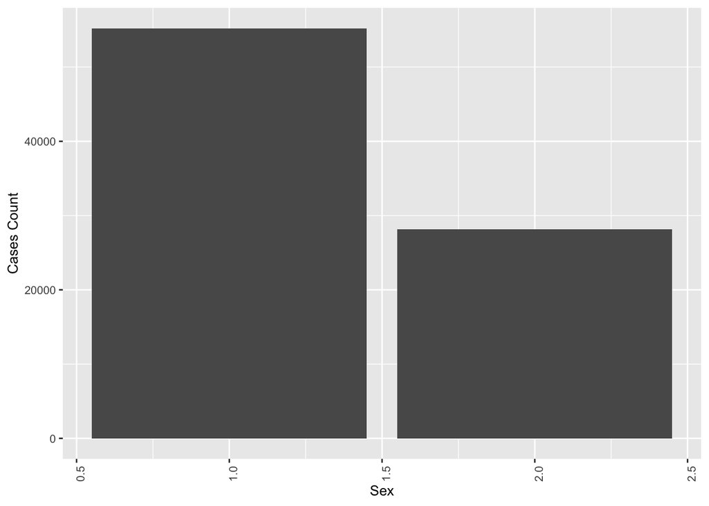

```r
ggplot(sex, aes(x=SEX, y=CasesCount)) +
  geom_bar(stat = "identity") +
  theme(text = element_text(size=10), axis.text.x = element_text(angle = 90, hjust=1)) +
  labs(y = "Cases Count", x = "Sex")
```

**Sex vs Cases Count**  
From the bar chart shown above, we can see that the male has more accident cases than the female. The male has over 40000 accident cases compared to woman which consist only around 25000 accident cases.

## Question 6

Now plot a choropleth map of the number of deaths on a county level. Also explain what you find.

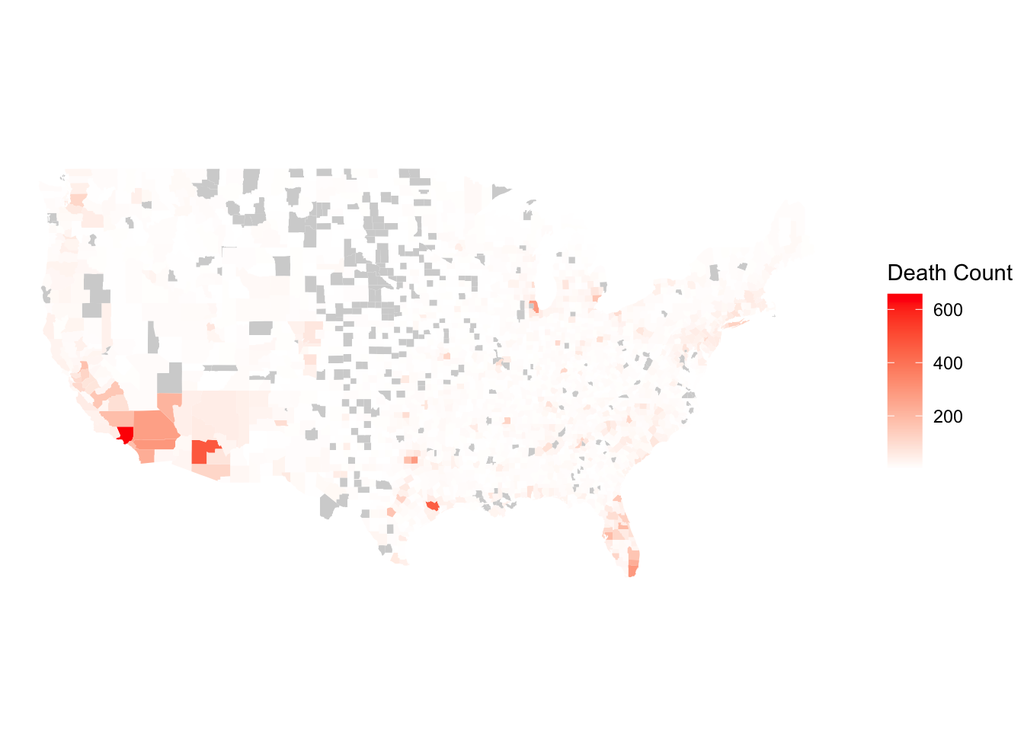

```r
deathCountyLevel <- personAccident %>%
                    filter(INJ_SEV == 4) %>%
                    group_by(STATE.x, COUNTY.x) %>%
                    summarize(`Death Count` = n()) %>%
                    rename(state = STATE.x, county = COUNTY.x) %>%
                    mutate(state = as.character(state), county = as.character(county))

count_county <- map_data("county") %>%
                  mutate(subregion = toupper(subregion), region = toupper(region)) %>%
                  left_join(glc %>%
                            select(`County Code`, `County Name`, `State Name`, `State Code`) %>%
                            distinct, by = c(subregion = 'County Name', region = 'State Name')) %>%
                  left_join(deathCountyLevel %>%
                            mutate(county = as.character(county)),
                            by = c(`County Code` = 'county', `State Code` = 'state'))

map <- count_county %>%
        ggplot(aes(x = long, y = lat)) +
        geom_polygon(aes(fill = `Death Count`, group = group)) +
        theme_nothing(legend = TRUE) +
        coord_map() +
        scale_fill_viridis(option = "magma", direction = -1)


map2 <- map + scale_fill_gradient2(low = "yellow", high = "red", na.value = "lightgrey",)

map2
```